# 6 Estadística riemanniana: grupos y trayectorias

**NotaEn este capítulo**

**Pregunta.** ¿Cómo comparo grupos y visitas?

**Objetivos.** Contrastar «¿difieren dos grupos de matrices?» y «¿ha cambiado una persona entre T1 y T2?» con tests de permutación válidos por construcción, calibrar su error de tipo I y estimar su potencia para cuatro representaciones (euclídea, log-euclídea, afín-invariante y log-varianza) sobre **las mismas matrices y las mismas particiones**. Reconocer dos trampas: tratar épocas como sujetos y ajustar con datos de prueba.

**Prerrequisitos.** Capítulos 3 (suelo de ruido), 4 (distancias e invariancia) y 5 (centros, espacio tangente, re-centrado).

**Código.** Los tests y el generador de la cohorte son provisionales y viven en el capítulo; pasarán a `NeuroRiemann.jl` con la cohorte (apéndice D). Todo es sintético, con semilla fija.

## 6.1 La pregunta

Los dos objetivos científicos del libro (capítulo 1) son contrastes: **transversal** (¿se diferencian las matrices de pacientes con EM y de controles?) y **longitudinal** (¿cambian las matrices de una persona entre dos visitas?). Con decenas de sujetos, la pregunta es inferencial: hay que decidir si la diferencia observada supera lo que produciría el azar, y el azar incluye tanto la variabilidad entre personas como el ruido de estimación de cada matriz (suelo de ruido, capítulo 3).

La estructura de los datos es jerárquica: **grupo → sujeto → visita → época → canal**. Las épocas de un mismo sujeto y visita no son observaciones independientes de la población; el **sujeto** es la unidad de análisis. Su covarianza se estima con las $K$ épocas de la visita (la media aritmética de las covarianzas de las épocas es la covarianza de los datos agregados, capítulo 2).

## 6.2 Contrastar con permutaciones

Un test de permutación no supone ninguna distribución para las matrices. Solo supone que, bajo la hipótesis nula, **las etiquetas son intercambiables**: reasignarlas al azar no cambia la ley de los datos.

Sea $v_1,\dots,v_N$ un vector por sujeto, $T(\ell)$ un estadístico que depende de las etiquetas $\ell\in\{A,B\}^N$ y $T_0$ su valor observado. Con $B$ permutaciones aleatorias independientes de las etiquetas, el **valor $p$** es
$$p=\frac{1+\#\{b: T_b\ge T_0\}}{B+1}.
\tag{6.1}$$

**Teorema 6.1 (Validez del test de permutación)** Si bajo $H_0$ la distribución de los datos es invariante por permutaciones de las etiquetas, entonces $\Pr(p\le\alpha)\le\alpha$ para todo $\alpha\in[0,1]$, sea cual sea el estadístico, el tamaño muestral y el valor de $B$. Demostrado

**NotaDemostración de la validez**

*Demostración*. Bajo $H_0$, $T_0,T_1,\dots,T_B$ son intercambiables: los $T_b$ se obtienen con permutaciones uniformes e independientes, y la ley de los datos es invariante por esas permutaciones, de modo que intercambiar $T_0$ con $T_b$ (equivale a componer con la permutación inversa, también uniforme) no cambia la ley conjunta. Sea $k=\lfloor\alpha(B+1)\rfloor$ y $E_i=\{\#\{j:T_j\ge T_i\}\le k\}$. Como mucho $k$ de los $B+1$ sucesos $E_i$ ocurren a la vez: si ocurrieran $m>k$, el menor de esos $T_i$ tendría al menos $m$ valores mayores o iguales, contra $E_i$. Por tanto $\sum_i\Pr(E_i)\le k$ y, por intercambiabilidad, $\Pr(E_0)\le k/(B+1)\le\alpha$. Pero $E_0=\{(B+1)p\le k\}\supseteq\{p\le\alpha\}$.

El «+1» del numerador y del denominador es lo que hace válido el test con $B$ finito. Para los contrastes pareados se usa la variante de **cambio de signo**: si bajo $H_0$ la diferencia $\Delta_s=g(P_s^{T2})-g(P_s^{T1})$ de cada sujeto tiene una distribución simétrica respecto de $0$, cualquiera de los $2^N$ vectores de signos $\pm\Delta_s$ es igual de verosímil, y se calcula la proporción de ellos con estadístico $\ge$ el observado (exacta, enumerando los $2^N$). La demostración del Teorema 6.1 es la misma con el grupo de cambios de signo.

### 6.2.1 Cuatro formas de resumir una matriz

Todos los estadísticos de este capítulo son de la misma forma: se lleva cada matriz a un vector y se mide la distancia euclídea entre las medias de los dos grupos. Cambia el vector (con la vectorización isométrica de la Proposición 5.5):

Tabla 6.1: Estadísticos de comparación de grupos.

| Estadístico | Vector de una matriz $P$ | Interpretación |
| --- | --- | --- |
| **E** (euclídeo) | $\operatorname{vec}(P)$ | distancia euclídea entre las medias aritméticas |
| **LE** (log-euclídeo) | $\operatorname{vec}(\Logm P)$ | $\dLE$ entre las medias log-euclídeas |
| **AI** (afín-invariante, tangente) | $\operatorname{vec}\big(\Logm(M^{-1/2}PM^{-1/2})\big)$, con $M$ la media de Karcher de **todas** las matrices | primer orden de $\dAI$ entre las medias de grupo |
| **LV** (log-varianza) | $(\log P_{11},\dots,\log P_{nn})$ | cambio de potencia por canal en dB; la referencia convencional |

Que la media de grupo en E y en LE sea el centro de Fréchet de cada geometría es la Proposición 5.1: para ellos el estadístico **es** la distancia entre centros. Para AI se usa la versión tangente en la media común, que es barata y válida: $M$ no depende de las etiquetas, así que los vectores son fijos y el Teorema 6.1 se aplica tal cual; la distancia entre las medias de Karcher de cada grupo coincide con ella a primer orden (Tabla 5.2 del capítulo 5).

**Código**

```julia
using NeuroRiemann, LinearAlgebra, StableRNGs, Statistics, Random, CairoMakie

# ---- generador provisional de la cohorte (un factor nuevo por capítulo: efectos de grupo y de progresión) ----
const n = 4
simetrica(rng, n) = (Z = randn(rng, n, n); (Z + Z') / 2)
muestra(rng, Σ, T) = (X = cholesky(Σ).L * randn(rng, size(Σ, 1), T); Symmetric(X * X' / T))
vec_iso(S) = [i == j ? S[i, j] : sqrt(2) * S[i, j] for i in 1:size(S, 1) for j in i:size(S, 1)]
blanquear(M, P) = (Mih = invsqrtm(M); symmetrize(Mih * P * Mih))

function karcher(Ps; tol = 1e-8, maxit = 100)
    M = symmetrize(mean(Ps))
    for _ in 1:maxit
        S = mean(logm(blanquear(M, P)) for P in Ps)
        M = symmetrize(sqrtm(M) * expm(symmetrize(S)) * sqrtm(M))
        norm(S) < tol && return M
    end
    return M
end

# Σ₀ fija (autovalores 10, 4, 1, 0,3) y heterogeneidad entre sujetos Σ_s = Σ₀^{1/2} exp(τ G_s) Σ₀^{1/2}
const Σ0 = let rng = StableRNG(11), Q = Matrix(qr(randn(rng, n, n)).Q)
    symmetrize(Q * Diagonal([10.0, 4.0, 1.0, 0.3]) * Q')
end
const U_DOM = eigen(Σ0).vectors[:, end]            # dirección de mayor varianza
const U_DEB = eigen(Σ0).vectors[:, 1]              # dirección de menor varianza
sujeto(rng; τ = 0.25) = (Σh = sqrtm(Σ0); symmetrize(Σh * expm(symmetrize(τ * simetrica(rng, n))) * Σh))

"Covarianza del grupo B: el efecto se aplica a la covarianza verdadera de cada sujeto."
function efecto(tipo, δ, Σ)
    cong(u, a) = (V = I + (exp(a / 2) - 1) * u * u'; symmetrize(V * Σ * V'))     # multiplica por e^a la varianza en la dirección u
    tipo === :nulo && return Σ
    tipo === :canal && return cong((1:n .== 1) * 1.0, δ)
    tipo === :dominante && return cong(U_DOM, δ)
    tipo === :debil && return cong(U_DEB, δ)
    d = sqrt(Σ[1, 1] * Σ[2, 2]) * δ                                                # :acoplamiento: sube la correlación 1–2 sin tocar varianzas
    for f in (1, 0.5, 0.25, 0.1, 0.0)
        Σb = Matrix(Σ); Σb[1, 2] += f * d; Σb[2, 1] += f * d
        isposdef(Σb) && return symmetrize(Σb)
    end
end

datos(rng, tipo, δ, T; nA = 10, nB = 10) =
    vcat([muestra(rng, sujeto(rng), T) for _ in 1:nA], [muestra(rng, efecto(tipo, δ, sujeto(rng)), T) for _ in 1:nB])

"Los cuatro vectores por sujeto de la @tbl-estadisticos."
function vectores(Ps)
    M = karcher(Ps)
    return (E = [vec_iso(P) for P in Ps], LE = [vec_iso(logm(P)) for P in Ps],
            AI = [vec_iso(logm(blanquear(M, P))) for P in Ps], LV = [log.(diag(P)) for P in Ps])
end

"Valor p de permutación (@eq-pvalor) del estadístico ‖media(A) − media(B)‖."
function pvalor(V, nA, rng; B = 499)
    idx = collect(eachindex(V))
    est(i) = norm(mean(V[i[1:nA]]) - mean(V[i[nA+1:end]]))
    obs = est(idx); c = 0
    for _ in 1:B
        shuffle!(rng, idx); c += est(idx) >= obs
    end
    return (1 + c) / (B + 1)
end
nothing
```

**Código**

```julia
# Compruébalo: para E y LE el estadístico es exactamente la distancia entre los centros de Fréchet (@prp-centros-planos).
rng = StableRNG(1)
Ps = datos(rng, :nulo, 0.0, 24)
V = vectores(Ps)
A, B = Ps[1:10], Ps[11:20]
(E = norm(mean(V.E[1:10]) - mean(V.E[11:20])) - distance(Euclidean(), symmetrize(mean(A)), symmetrize(mean(B))),
 LE = norm(mean(V.LE[1:10]) - mean(V.LE[11:20])) - distance(LogEuclidean(), expm(symmetrize(mean(logm.(A)))), expm(symmetrize(mean(logm.(B))))))
```

```
(E = 2.220446049250313e-16, LE = 1.8318679906315083e-15)
```

Las dos diferencias son del orden de $10^{-15}$ Verificado numéricamente.

## 6.3 Experimento 1: error de tipo I, potencia y el mapa de fases

**Cohorte sintética.** Cada sujeto tiene una covarianza $\Sigma_s=\Sigma_0^{1/2}\exp(\tau G_s)\Sigma_0^{1/2}$ con $G_s$ simétrica gaussiana y $\tau=0{,}25$ (variabilidad entre personas), y su matriz observada es la covarianza muestral de $T$ muestras independientes, con $n=4$ canales ($T=6$, $24$ y $96$ dan $T/n=1{,}5$, $6$ y $24$; el caso $T/n=1{,}5$ es casi singular). Hay 10 sujetos por grupo. El grupo B recibe uno de cuatro efectos hipotéticos, declarados de antemano y de la misma magnitud relativa:

Tabla 6.2: Efectos de grupo del experimento. Los tamaños se fijaron para que la potencia recorra un rango informativo; no están calibrados con datos reales.

| Efecto del grupo B | Qué cambia | Magnitud |
| --- | --- | --- |
| Nulo | nada | — |
| **Canal** | potencia en un solo canal (el 1) | varianza $\times e^{0{,}4}\approx1{,}5$ ($+1{,}7$ dB) |
| **Dominante** | potencia en la dirección de mayor varianza de $\Sigma_0$ | varianza $\times1{,}5$ en esa dirección |
| **Débil** | potencia en la dirección de menor varianza de $\Sigma_0$ | varianza $\times1{,}5$ en esa dirección |
| **Acoplamiento** | correlación entre los canales 1 y 2, sin tocar ninguna varianza | $+0{,}2\sqrt{\Sigma_{11}\Sigma_{22}}$ en la covarianza (se reduce a la mitad si la matriz dejara de ser SPD) |

Para cada celda se generan $R=200$ cohortes y se aplican los cuatro estadísticos de la Tabla 6.1 **a las mismas cohortes y con las mismas permutaciones** ($B=499$), de modo que lo único que cambia es la representación. Se declara además la potencia a $\alpha=0{,}05$ y su error estándar Monte Carlo, que es a lo sumo $0{,}035$.

**Código**

```julia
function mapa_de_fases(; R = 200, Ts = (6, 24, 96))
    efectos = ((:nulo, 0.0), (:canal, 0.4), (:dominante, 0.4), (:debil, 0.4), (:acoplamiento, 0.2))
    filas = NamedTuple[]
    for (k, (tipo, δ)) in enumerate(efectos), T in Ts
        rng = StableRNG(1000k + T)
        acc = Dict(k => 0 for k in (:E, :LE, :AI, :LV))
        for _ in 1:R
            V = vectores(datos(rng, tipo, δ, T))
            for k in keys(acc)
                acc[k] += pvalor(V[k], 10, rng) <= 0.05
            end
        end
        push!(filas, (; tipo, T, E = acc[:E] / R, LE = acc[:LE] / R, AI = acc[:AI] / R, LV = acc[:LV] / R))
    end
    return filas
end
grid = mapa_de_fases()
nombres_efecto = Dict(:nulo => "Nulo", :canal => "Canal", :dominante => "Dominante", :debil => "Débil", :acoplamiento => "Acoplamiento")
println("| Efecto | \$T/n\$ | E | LE | AI | LV |\n|---|---|---|---|---|---|")
for f in grid
    println("| ", nombres_efecto[f.tipo], " | ", f.T / n, " | ", join((f.E, f.LE, f.AI, f.LV), " | "), " |")
end
println("\n: Fracción de cohortes con \$p\\le0{,}05\$ (200 por celda): error de tipo I en la fila «Nulo» y potencia en las demás. {#tbl-potencia}")
# prueba numérica: el error de tipo I está bajo control (cota nominal más tres errores estándar)
tipoI = [getfield(f, k) for f in grid if f.tipo === :nulo for k in (:E, :LE, :AI, :LV)]
maximum(tipoI) <= 0.05 + 3 * sqrt(0.05 * 0.95 / 200) || error("error de tipo I fuera de control: ", maximum(tipoI))
```

Tabla 6.3: Fracción de cohortes con $p\le0{,}05$ (200 por celda): error de tipo I en la fila «Nulo» y potencia en las demás.

| Efecto | $T/n$ | E | LE | AI | LV |
| --- | --- | --- | --- | --- | --- |
| Nulo | 1.5 | 0.045 | 0.055 | 0.065 | 0.05 |
| Nulo | 6.0 | 0.065 | 0.065 | 0.075 | 0.04 |
| Nulo | 24.0 | 0.05 | 0.065 | 0.045 | 0.035 |
| Canal | 1.5 | 0.085 | 0.125 | 0.115 | 0.135 |
| Canal | 6.0 | 0.115 | 0.43 | 0.435 | 0.36 |
| Canal | 24.0 | 0.125 | 0.695 | 0.71 | 0.575 |
| Dominante | 1.5 | 0.23 | 0.115 | 0.105 | 0.22 |
| Dominante | 6.0 | 0.585 | 0.27 | 0.25 | 0.545 |
| Dominante | 24.0 | 0.82 | 0.53 | 0.495 | 0.72 |
| Débil | 1.5 | 0.03 | 0.09 | 0.095 | 0.045 |
| Débil | 6.0 | 0.05 | 0.31 | 0.28 | 0.055 |
| Débil | 24.0 | 0.055 | 0.54 | 0.485 | 0.07 |
| Acoplamiento | 1.5 | 0.06 | 0.245 | 0.255 | 0.055 |
| Acoplamiento | 6.0 | 0.05 | 0.66 | 0.675 | 0.03 |
| Acoplamiento | 24.0 | 0.07 | 0.91 | 0.925 | 0.05 |

```
true
```

**Código**

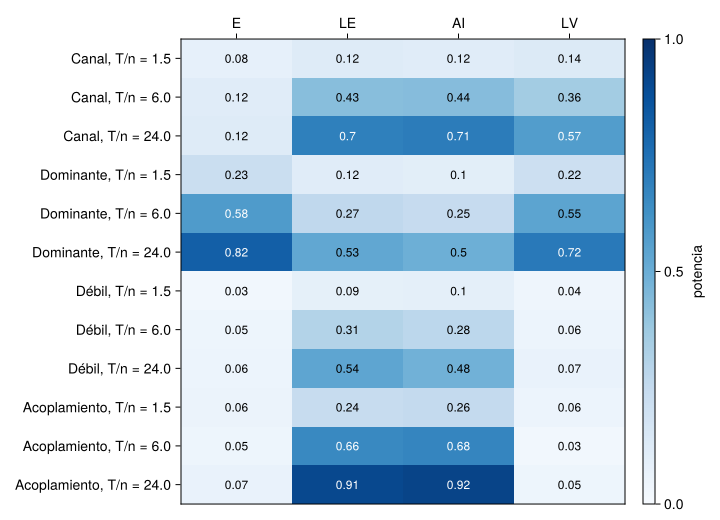

Figura 6.1: Mapa de fases: potencia a $\alpha=0{,}05$ de cada estadístico (columnas) según el tipo de efecto y $T/n$ (filas). Más oscuro, más potencia. Resultado del modelo sintético declarado, no un ranking de métodos.

```julia
filas_efecto = [f for f in grid if f.tipo !== :nulo]
M = reduce(vcat, [[f.E f.LE f.AI f.LV] for f in filas_efecto])
etiquetas = ["$(nombres_efecto[f.tipo]), T/n = $(f.T / n)" for f in filas_efecto]
fig = Figure(size = (720, 520))
ax = Axis(fig[1, 1]; xticks = (1:4, ["E", "LE", "AI", "LV"]), yticks = (1:length(etiquetas), reverse(etiquetas)), yreversed = false,
          xaxisposition = :top)
hm = heatmap!(ax, 1:4, 1:size(M, 1), permutedims(M[end:-1:1, :]); colormap = :Blues, colorrange = (0, 1))
for i in 1:size(M, 1), j in 1:4
    text!(ax, j, size(M, 1) + 1 - i; text = string(round(M[i, j]; digits = 2)), align = (:center, :center),
          color = M[i, j] > 0.55 ? :white : :black, fontsize = 12)
end
Colorbar(fig[1, 2], hm; label = "potencia")
fig
```

Es un **mapa de condiciones del modelo declarado, no un ranking**: los tamaños de efecto (Tabla 6.2) y $\Sigma_0$ los fijé yo, y con otros valores la frontera entre regiones se desplazaría. Lo que enseña es que la pregunta «¿qué geometría es mejor?» solo tiene respuesta una vez dicho **qué efecto se espera**.

### 6.3.1 El error de tratar épocas como sujetos

Cada sujeto aporta $K$ épocas. Si se permutan las etiquetas **de las épocas** en lugar de las de los sujetos, el test supone que las épocas son independientes, y no lo son: dos épocas del mismo sujeto se parecen más que dos de sujetos distintos.

**Código**

```julia
function pseudorreplicacion(; R = 300, K = 10, T = 24, ns = 5, τ = 0.4)
    rng = StableRNG(9); acierto = zeros(2)
    for _ in 1:R
        E = Vector{Vector{Float64}}(); sub = Int[]
        for s in 1:2ns
            Σs = sujeto(rng; τ)
            for _ in 1:K
                push!(E, vec_iso(logm(muestra(rng, Σs, T)))); push!(sub, s)
            end
        end
        acierto[1] += pvalor([mean(E[sub .== s]) for s in 1:2ns], ns, rng) <= 0.05     # unidad: el sujeto
        acierto[2] += pvalor(E, ns * K, rng) <= 0.05                                   # unidad: la época
    end
    return acierto ./ R
end
tipoI_sujeto, tipoI_epoca = pseudorreplicacion()
println("| Unidad que se permuta | Error de tipo I (nominal 0,05) |\n|---|---|")
println("| Sujeto (correcto) | ", tipoI_sujeto, " |\n| Época (pseudorreplicación) | ", tipoI_epoca, " |")
println("\n: Error de tipo I con 5 sujetos por grupo, 10 épocas por sujeto, sin efecto (300 cohortes, estadístico LE). {#tbl-pseudo}")
```

Tabla 6.4: Error de tipo I con 5 sujetos por grupo, 10 épocas por sujeto, sin efecto (300 cohortes, estadístico LE).

| Unidad que se permuta | Error de tipo I (nominal 0,05) |
| --- | --- |
| Sujeto (correcto) | 0.04 |
| Época (pseudorreplicación) | 0.9933333333333333 |

Permutar épocas rechaza una hipótesis nula verdadera en el $99\,\%$ de las cohortes (Tabla 6.4): las diferencias entre personas se toman por diferencias entre grupos Verificado numéricamente. Es un error de diseño, no de geometría, y ningún estadístico lo corrige.

## 6.4 Experimento 2: dos trampas

### 6.4.1 Una progresión falsa en el contraste longitudinal

Doce sujetos con una visita T1 y otra T2, **sin cambio cerebral**, pero con las ganancias de un electrodo distintas en T2 (potencia $\times1{,}5$ en el canal 1). Se aplica el contraste pareado de cambio de signo a cuatro estadísticos: E, LE, LV y **Corr**, que usa el vector de correlaciones $(\operatorname{Corr}(P)_{ij})_{i<j}$ y por tanto no depende de las ganancias diagonales (Proposición 2.5). El estadístico es la norma de la media de las diferencias de vectores.

**Código**

```julia
function pareado(tipo; R = 1000, N = 12, T = 24)
    rng = StableRNG(21)
    signos = Float64[(c >> (i - 1)) & 1 == 1 ? -1 : 1 for c in 0:2^N-1, i in 1:N]      # 2^N × N: todos los vectores de signos
    corrv(P) = (d = 1 ./ sqrt.(diag(P)); C = Diagonal(d) * P * Diagonal(d); [C[i, j] for i in 1:n for j in i+1:n])
    f = (E = vec_iso, LE = P -> vec_iso(logm(P)), LV = P -> log.(diag(P)), Corr = corrv)
    acc = Dict(k => 0 for k in keys(f))
    for _ in 1:R
        Sg = [sujeto(rng) for _ in 1:N]
        P1 = [muestra(rng, Σ, T) for Σ in Sg]
        P2 = [muestra(rng, tipo === :nulo ? Σ : efecto(:canal, 0.4, Σ), T) for Σ in Sg]
        for k in keys(f)
            Δ = reduce(hcat, [f[k](P2[i]) - f[k](P1[i]) for i in 1:N])'                  # N × d
            est = vec(sqrt.(sum(abs2, signos * Δ / N; dims = 2)))
            acc[k] += mean(est .>= est[1] - 1e-12) <= 0.05                               # signos[1, :] = +1: estadístico observado
        end
    end
    return Dict(k => v / R for (k, v) in acc)
end
sin_cambio, con_ganancia = pareado(:nulo), pareado(:ganancia)
println("| Situación | E | LE | LV | Corr |\n|---|---|---|---|---|")
for (nombre, r) in (("Sin cambio de ganancias (error de tipo I)", sin_cambio), ("Ganancia ×1,5 solo en T2 (**falsa progresión**)", con_ganancia))
    println("| ", nombre, " | ", join((r[k] for k in (:E, :LE, :LV, :Corr)), " | "), " |")
end
println("\n: Fracción de cohortes con \$p\\le0{,}05\$ en el contraste pareado de 12 sujetos (1000 cohortes; contraste exacto con \$2^{12}\$ signos). {#tbl-pareado}")
maximum(values(sin_cambio)) <= 0.05 + 3 * sqrt(0.05 * 0.95 / 1000) || error("error de tipo I del contraste pareado fuera de control")
```

Tabla 6.5: Fracción de cohortes con $p\le0{,}05$ en el contraste pareado de 12 sujetos (1000 cohortes; contraste exacto con $2^{12}$ signos).

| Situación | E | LE | LV | Corr |
| --- | --- | --- | --- | --- |
| Sin cambio de ganancias (error de tipo I) | 0.044 | 0.049 | 0.049 | 0.045 |
| Ganancia ×1,5 solo en T2 (**falsa progresión**) | 0.129 | 0.724 | 0.648 | 0.045 |

```
true
```

Una ganancia distinta solo en T2 produce un «cambio» que LE y LV detectan en la mayoría de las cohortes ($0{,}72$ y $0{,}65$) y E en una de cada ocho, porque el cambio de potencia del canal 1 pesa poco en valor absoluto (Tabla 6.5) Verificado numéricamente: es el caso (ii) del capítulo 4, y no hay estadístico de distancia que lo distinga de un cambio real. **Corr no lo ve** (su tasa de rechazo es la del error de tipo I), porque $\operatorname{Corr}(DPD)=\operatorname{Corr}(P)$; el precio es que ya no ve ningún cambio **de potencia**, que es información fisiológica. El contraste pareado es exacto en los cuatro casos: el error de tipo I es el nominal.

Y una nota sobre el **re-centrado por sujeto** (capítulo 5): si cada sujeto se re-centra en su propia media, la media de cada sujeto pasa a ser la identidad, y **cualquier diferencia de medias entre grupos vale cero idénticamente**. Solo quedan los efectos sobre la dispersión y la forma. Re-centrar por sujeto no es una opción neutra: borra justo lo que los estadísticos de esta sección miden.

### 6.4.2 Un clasificador que acierta con datos nulos

El **clasificador de distancia mínima a la media** (MDM) asigna cada matriz a la clase cuyo centro de Fréchet está más cerca (Barachant et al. 2013). Se evalúa con validación cruzada dejando un sujeto fuera. Con 24 sujetos (12 por grupo) **sin ningún efecto**, comparamos dos canalizaciones: la correcta, que calcula los centros solo con los sujetos de entrenamiento, y una con **fuga**, que los calcula con todos los sujetos, incluido el que se evalúa.

**Código**

```julia
function experimento_mdm(; R = 60, N = 24, T = 24)
    rng = StableRNG(33); res = zeros(4)
    y = repeat([1, 2]; inner = N ÷ 2)
    for _ in 1:R
        Ps = [muestra(rng, sujeto(rng; τ = 0.4), T) for _ in 1:N]
        for (j, fuga) in enumerate((false, true))
            okAI = okE = 0
            for i in 1:N
                ent = fuga ? collect(1:N) : setdiff(1:N, i)
                A, B = Ps[[k for k in ent if y[k] == 1]], Ps[[k for k in ent if y[k] == 2]]
                m1, m2 = karcher(A), karcher(B)
                okAI += (distance(AffineInvariant(), Ps[i], m1) < distance(AffineInvariant(), Ps[i], m2) ? 1 : 2) == y[i]
                e1, e2 = symmetrize(mean(A)), symmetrize(mean(B))
                okE += (norm(Ps[i] - e1) < norm(Ps[i] - e2) ? 1 : 2) == y[i]
            end
            res[2j-1] += okAI / N; res[2j] += okE / N
        end
    end
    return res ./ R
end
r = experimento_mdm()
println("| Canalización | MDM afín-invariante | MDM euclídeo |\n|---|---|---|")
println("| Sin fuga (centros con el conjunto de entrenamiento) | ", round(r[1]; digits = 3), " | ", round(r[2]; digits = 3), " |")
println("| **Con fuga** (centros con todos los sujetos) | ", round(r[3]; digits = 3), " | ", round(r[4]; digits = 3), " |")
println("\n: Exactitud media del MDM con validación cruzada dejando uno fuera, 24 sujetos y ningún efecto (60 cohortes; el azar es 0,5). {#tbl-mdm}")
nothing
```

Tabla 6.6: Exactitud media del MDM con validación cruzada dejando uno fuera, 24 sujetos y ningún efecto (60 cohortes; el azar es 0,5).

| Canalización | MDM afín-invariante | MDM euclídeo |
| --- | --- | --- |
| Sin fuga (centros con el conjunto de entrenamiento) | 0.483 | 0.492 |
| **Con fuga** (centros con todos los sujetos) | 0.73 | 0.626 |

Sin fuga, la exactitud es la del azar ($0{,}5$); con fuga, el clasificador «acierta» con datos que no contienen ninguna señal (Tabla 6.6) Verificado numéricamente. Cada sujeto contribuye a su propio centro y queda más cerca de él. Es la misma regla para todo lo que se ajusta con datos: **el centro de cada clase, la contracción $\lambda$ elegida por una regla de los datos (capítulo 3) y cualquier re-centrado que dependa de las etiquetas deben calcularse solo con el conjunto de entrenamiento de cada partición.** El re-centrado con la media global de todas las matrices **sin usar etiquetas**, como la $M$ de la Tabla 6.1, no filtra etiquetas, pero sí usa los datos de prueba; es una decisión que debe declararse.

## 6.5 Lo que esto no demuestra

- **No demuestra que una geometría sea mejor.** El mapa de fases describe un modelo concreto (cuatro canales, 10 sujetos por grupo, $\Sigma_0$ y tamaños de efecto fijados por el autor): con otros valores, las regiones cambian. LE y AI no se distinguen aquí, y la comparación entre ellas **no** prueba que la invariancia afín sea inútil: no hay ganancias distintas entre sujetos que compensar.
- **El estadístico AI es el de espacio tangente en la media común,** una aproximación de primer orden a la distancia entre medias de Karcher. Es válido, pero no equivale al contraste con las medias de Karcher de cada grupo.
- **La validez de un test de permutación exige intercambiabilidad** bajo $H_0$. Con diseños que no la cumplen (covariables que difieren entre grupos, medidas repetidas mal modeladas, sujetos que son familiares entre sí) el test puede no ser válido. Este capítulo no trata modelos con covariables.
- **No se ha calibrado nada con datos reales** ni se han comparado los efectos con los de NeuroMIND. Los resultados valen para la cohorte sintética Hipótesis sintética.
- **La potencia depende de $T$ efectivo,** no solo de $T$ (capítulo 3). Aquí las muestras son independientes; con autocorrelación, $T/n$ efectivo es menor y todas las regiones se desplazan.
- **El diseño jerárquico se ha reducido a una matriz por sujeto** (y a una por visita). No se modela la variabilidad intra-sujeto entre épocas ni se combinan visitas dentro del mismo modelo.
- **El MDM es la referencia más simple.** No se ha tratado la regresión sobre el espacio tangente, el CSP ni el aprendizaje profundo, y la tasa de acierto con datos reales es una cuestión empírica que no se estudia aquí.

## 6.6 Autoevaluación

**TipCien épocas, diez sujetos**

Diez sujetos aportan diez épocas cada uno. Un colega permuta las 100 épocas entre los grupos y obtiene $p=0{,}001$. ¿Es fiable?

**Respuesta.** No: el test supone épocas intercambiables y no lo son (el sujeto es la unidad de análisis). Con heterogeneidad entre sujetos el error de tipo I se dispara (Tabla 6.4). Hay que permutar sujetos.

**TipCorr y la ganancia**

En un estudio longitudinal, ¿por qué la distancia entre matrices de correlación no detecta una ganancia distinta en T2, y qué coste tiene?

**Respuesta.** Porque $\operatorname{Corr}(DPD)=\operatorname{Corr}(P)$ (Proposición 2.5). El coste es que tampoco detecta ningún cambio real de potencia, que es información fisiológica (Tabla 6.5).

**TipUn clasificador demasiado bueno**

Un clasificador MDM obtiene el $75\,\%$ de exactitud con 24 sujetos y sin efecto conocido. ¿Qué sospecharías?

**Respuesta.** Una fuga: algún elemento ajustado con los datos (centros, contracción, re-centrado) incluye al sujeto evaluado (Tabla 6.6). Con datos sin señal, la exactitud debe ser $\approx0{,}5$.

**TipRe-centrar y comparar (repaso del capítulo 5)**

Si se re-centra cada sujeto en su propia media de Fréchet, ¿qué vale la diferencia entre las medias de dos grupos?

**Respuesta.** Cero, porque la media de cada sujeto es la identidad (capítulo 5). El re-centrado conserva la dispersión y borra la localización, también la fisiológica.

## 6.7 Ejercicios

**Ejercicio 6.1** Demuestra que el contraste de cambio de signo es válido: si bajo $H_0$ los $\Delta_s$ son independientes y simétricos respecto de $0$, entonces $\Pr(p\le\alpha)\le\alpha$ con $p$ la proporción de los $2^N$ vectores de signos con estadístico mayor o igual que el observado.

**TipPista**

Adapta la demostración del Teorema 6.1: el grupo es $\{\pm1\}^N$ y el vector $(\epsilon_1\Delta_1,\dots,\epsilon_N\Delta_N)$ tiene la misma ley que $(\Delta_1,\dots,\Delta_N)$ para cualquier $\epsilon$.

**Ejercicio 6.2** ¿Cuál es el menor valor $p$ posible con $B=499$ permutaciones? ¿Y en el contraste de cambio de signo con $N=12$?

**NotaSolución**

$1/(B+1)=1/500=0{,}002$, y $1/2^{12}=1/4096\approx2{,}4\cdot10^{-4}$ (o $2/4096$ si el contraste es bilateral y el estadístico no distingue el signo).

**Ejercicio 6.3** Con las funciones del laboratorio, estima cómo cambia la potencia de LE y AI en el efecto «Débil» al pasar de 10 a 20 sujetos por grupo. ¿Se parece el aumento al que predice $\sqrt{n}$?

**Ejercicio 6.4** (Laboratorio) Añade a `vectores` el estadístico **Corr** del Experimento 2 y calcula su potencia en el efecto «Acoplamiento». ¿Detecta algo que LV no ve?

**Ejercicio 6.5** Repite el Experimento 2 (MDM) con una contracción de la covarianza de parámetro $\lambda$ elegido para maximizar la exactitud de validación cruzada con todos los sujetos. ¿Cuánto infla la exactitud bajo el nulo?

Barachant, Alexandre, Stéphane Bonnet, Marco Congedo, y Christian Jutten. 2013. «Classification of Covariance Matrices Using a Riemannian-Based Kernel for BCI Applications». *Neurocomputing* 112: 172-78. https://doi.org/10.1016/j.neucom.2012.12.039.